# Assignment 5 R Notebook

Import necessary libraries

```r
library("caret")
library("rpart")
library("tree")
library("randomForest")
```

```r
library("e1071")
library("ggplot2")
```

### Step 1: Read and summarize the data

Using R, read the file seaflow_21min.csv and get the overall counts for each category of particle. The counts for each type of particle are in the pop column.

```r
sf <- read.csv("seaflow_21min.csv")
summary(sf)
```

```
##     file_id           time          cell_id            d1
##  Min.   :203.0   Min.   : 12.0   Min.   :    0   Min.   : 1328
##  1st Qu.:204.0   1st Qu.:174.0   1st Qu.: 7486   1st Qu.: 7296
##  Median :206.0   Median :362.0   Median :14995   Median :17728
##  Mean   :206.2   Mean   :341.5   Mean   :15008   Mean   :17039
##  3rd Qu.:208.0   3rd Qu.:503.0   3rd Qu.:22401   3rd Qu.:24512
##  Max.   :209.0   Max.   :643.0   Max.   :32081   Max.   :54048
##        d2          fsc_small        fsc_perp        fsc_big
##  Min.   :   32   Min.   :10005   Min.   :    0   Min.   :32384
##  1st Qu.: 9584   1st Qu.:31341   1st Qu.:13496   1st Qu.:32400
##  Median :18512   Median :35483   Median :18069   Median :32400
##  Mean   :17437   Mean   :34919   Mean   :17646   Mean   :32405
##  3rd Qu.:24656   3rd Qu.:39184   3rd Qu.:22243   3rd Qu.:32416
##  Max.   :54688   Max.   :65424   Max.   :63456   Max.   :32464
##        pe          chl_small        chl_big           pop
##  Min.   :    0   Min.   : 3485   Min.   :    0   crypto :  102
##  1st Qu.: 1635   1st Qu.:22525   1st Qu.: 2800   nano   :12698
##  Median : 2421   Median :30512   Median : 7744   pico   :20860
##  Mean   : 5325   Mean   :30164   Mean   : 8328   synecho:18146
##  3rd Qu.: 5854   3rd Qu.:38299   3rd Qu.:12880   ultra  :20537
##  Max.   :58675   Max.   :64832   Max.   :57184
```

### Step 2: Split the data into test and training sets

Divide the data into two equal subsets, one for training and one for testing.

```r
set.seed(1001)
trainIndex <- createDataPartition(sf$pop, times=1, list=FALSE)
sfTrain <- sf[trainIndex,]
sfTest  <- sf[-trainIndex,]
mean(sfTrain$time)
```

```
## [1] 341.0831
```

### Step 3: Plot the data

Plot pe against chl_small and color by pop

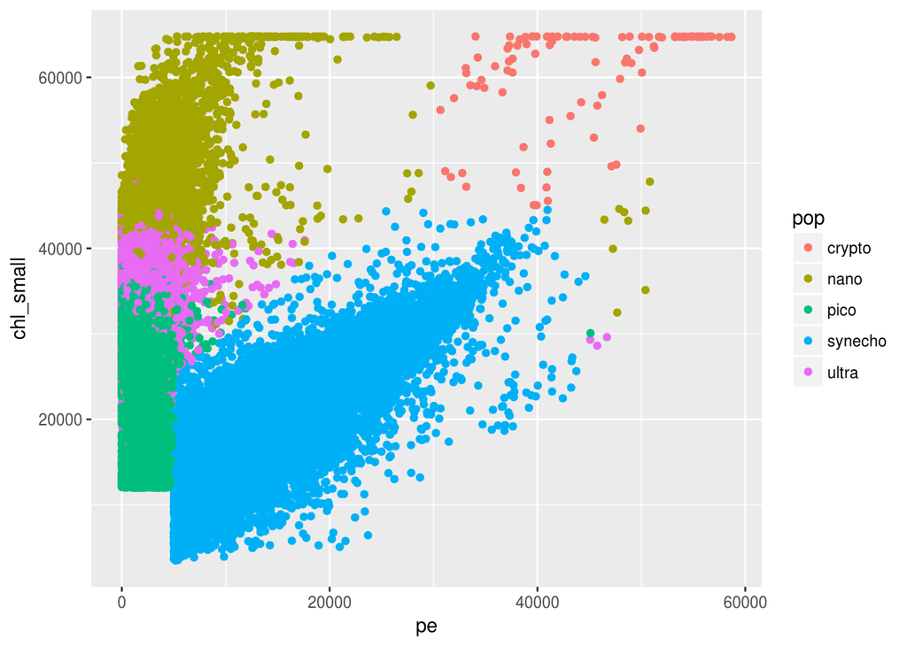

```r
ggplot(sf, aes(x=pe, y=chl_small, color=pop)) +
  geom_point()
```

### Step 4: Train a decision tree

Train a tree as a function of the sensor measurements: fsc_small + fsc_perp + fsc_big + pe + chl_big + chl_small Print the resulting model

```r
fol <- formula(pop ~ fsc_small + fsc_perp + fsc_big + pe + chl_big + chl_small)
dtModel <- rpart(fol, method="class", data=sfTrain)
print(dtModel)
```

```
## n= 36172
##
## node), split, n, loss, yval, (yprob)
##       * denotes terminal node
##
##  1) root 36172 25742 pico (0.0014 0.18 0.29 0.25 0.28)
##    2) pe< 5004 26322 15938 pico (0 0.22 0.39 7.6e-05 0.38)
##      4) chl_small< 32188 11399  1935 pico (0 0.00018 0.83 0.00018 0.17) *
##      5) chl_small>=32188 14923  6739 ultra (0 0.39 0.062 0 0.55)
##       10) chl_small>=41305.5 5210   671 nano (0 0.87 0.00019 0 0.13) *
##       11) chl_small< 41305.5 9713  2199 ultra (0 0.13 0.095 0 0.77) *
##    3) pe>=5004 9850   779 synecho (0.0052 0.054 0.0047 0.92 0.016)
##      6) chl_small>=39240 612   107 nano (0.083 0.83 0 0.039 0.052) *
##      7) chl_small< 39240 9238   191 synecho (0 0.0025 0.005 0.98 0.013) *
```

### Step 5: Evaluate the decision tree on the test data

Use the predict function to generate predictions on your test data. Then, compare these predictions with the class labels in the test data itself to get the model’s accuracy

```r
dtPredictions <- predict(dtModel, newdata=sfTest, type="class")
sum(dtPredictions == sfTest$pop) / nrow(sfTest)
```

```
## [1] 0.8548008
```

### Step 6: Build and evaluate a random forest

Build and evaluate a random forest model on the test data Call importance on the model to rank the Gini impurity of each of the features

```r
fol <- formula(pop ~ fsc_small + fsc_perp + fsc_big + pe + chl_big + chl_small)
rfModel <- randomForest(fol, method="class", data=sfTrain)
print(rfModel)
```

```
##
## Call:
##  randomForest(formula = fol, data = sfTrain, method = "class")
##                Type of random forest: classification
##                      Number of trees: 500
## No. of variables tried at each split: 2
##
##         OOB estimate of  error rate: 7.9%
## Confusion matrix:
##         crypto nano  pico synecho ultra  class.error
## crypto      49    0     0       2     0 0.0392156863
## nano         1 5532     0       7   809 0.1286816822
## pico         0    0 10088       8   334 0.0327900288
## synecho      1    3     0    9067     2 0.0006613028
## ultra        0  344  1344       4  8577 0.1647677476
```

```r
rfPredictions <- predict(rfModel, newdata=sfTest, type="class")
print(sum(rfPredictions == sfTest$pop) / nrow(sfTest))
```

```
## [1] 0.9197147
```

```r
importance(rfModel)
```

```
##           MeanDecreaseGini
## fsc_small        2589.8422
## fsc_perp         2126.7742
## fsc_big           202.4495
## pe               8887.6296
## chl_big          4986.8432
## chl_small        8061.2742
```

### Step 7: Train a support vector machine model and compare results

Use the e1071 library to build and evaluate a support vector machine model

```r
fol <- formula(pop ~ fsc_small + fsc_perp + fsc_big + pe + chl_big + chl_small)
svmModel <- svm(fol, data=sfTrain)
svmPredictions <- predict(svmModel, newdata=sfTest, type="class")
print(sum(svmPredictions == sfTest$pop) / nrow(sfTest))
```

```
## [1] 0.9198806
```

### Step 8: Construct confusion matrices

Use the table function to generate a confusion matrix for each of the three methods.

```r
table(pred=dtPredictions, true=sfTest$pop)
```

```
##          true
## pred      crypto nano pico synecho ultra
##   crypto       0    0    0       0     0
##   nano        51 4989    0      28   672
##   pico         0    2 9392       0  1990
##   synecho      0   24   46    9045   113
##   ultra        0 1334  992       0  7493
```

```r
table(pred=rfPredictions, true=sfTest$pop)
```

```
##          true
## pred      crypto  nano  pico synecho ultra
##   crypto      49     1     0       0     0
##   nano         2  5551     0       0   338
##   pico         0     0 10058       0  1384
##   synecho      0     2    15    9073    10
##   ultra        0   795   357       0  8536
```

```r
table(pred=svmPredictions, true=sfTest$pop)
```

```
##          true
## pred      crypto  nano  pico synecho ultra
##   crypto      46     2     0       1     0
##   nano         2  5624     0       2   372
##   pico         0     0 10054      26  1384
##   synecho      3     3    62    9042     5
##   ultra        0   720   314       2  8507
```

### Step 9: Sanity check the data

As a data scientist, you should never trust the data, especially if you did not collect it yourself. There is no such thing as clean data. You should always be trying to prove your results wrong by finding problems with the data. Richard Feynman calls it “bending over backwards to show how you’re maybe wrong.” This is even more critical in data science, because almost by definition you are using someone else’s data that was collected for some other purpose rather than the experiment you want to do. So of course it’s going to have problems.

The measurements in this dataset are all supposed to be continuous (fsc_small, fsc_perp, fsc_big, pe, chl_small, chl_big), but one is not. By plotting time against fsc_big we can see that fsc_big only takes on discrete values.

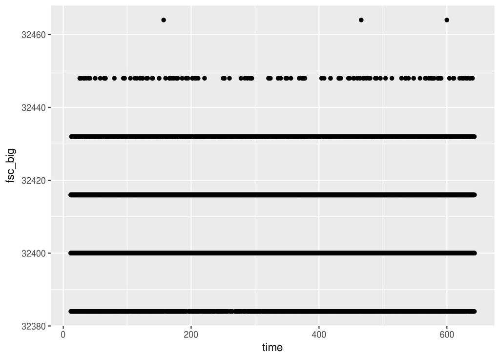

```r
ggplot(sf, aes(x=time, y=fsc_big)) + geom_point()
```

There is more subtle issue with data as well. Plot time vs. chl_big, and you will notice a band of the data looks out of place. This band corresponds to data from a particular file for which the sensor may have been miscalibrated.

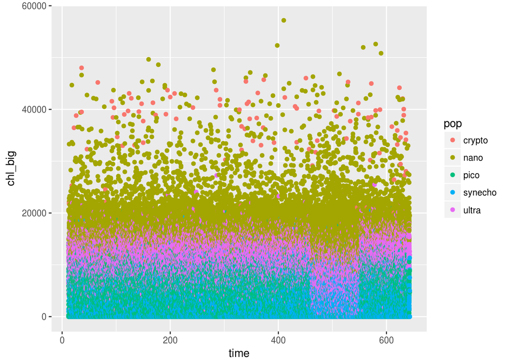

```r
ggplot(sf, aes(x=time, y=chl_big, color=pop)) +
  geom_point()
```

Remove this data from the dataset by filtering out all data associated with file_id 208

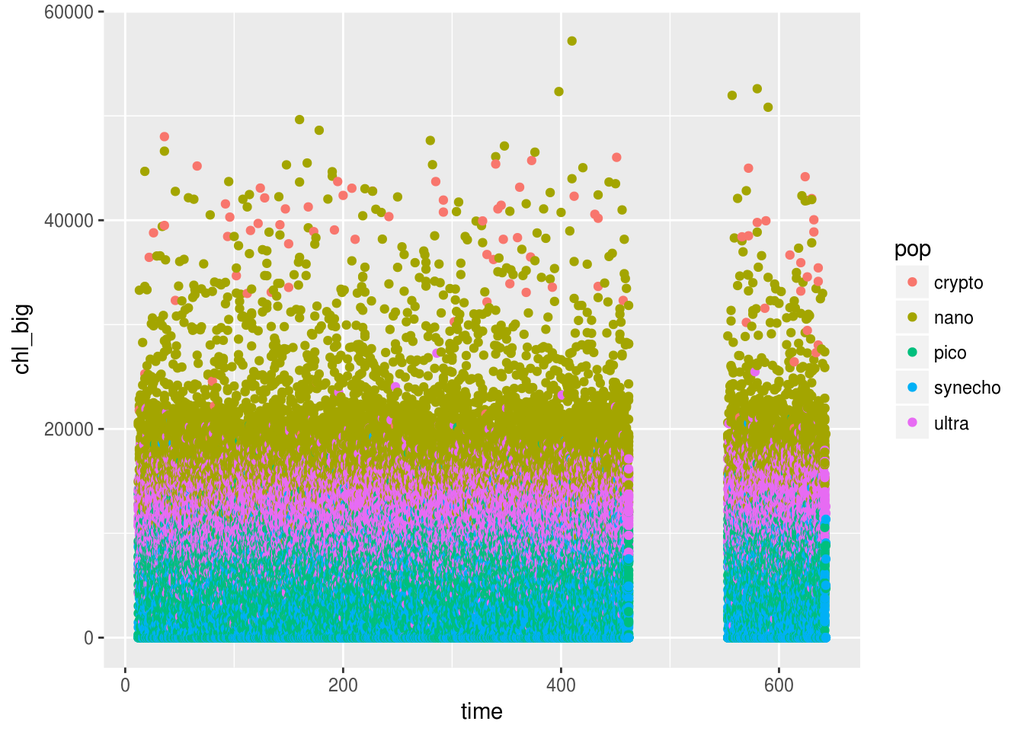

```r
sf <- sf[sf$file_id != 208, ]
ggplot(sf, aes(x=time, y=chl_big, color=pop)) +
  geom_point()
```

Then repeat the experiment for all three methods and evaluate

```r
trainIndex <- createDataPartition(sf$pop, times=1, list=FALSE)
sfTrain <- sf[trainIndex, ]
sfTest  <- sf[-trainIndex,]
fol <- formula(pop ~ fsc_small + fsc_perp + fsc_big + pe + chl_big + chl_small)
```

Decision Tree

```r
dtModel <- rpart(fol, method="class", data=sfTrain)
dtPredictions <- predict(dtModel, newdata=sfTest, type="class")
print(sum(dtPredictions == sfTest$pop) / nrow(sfTest))
```

```
## [1] 0.8923209
```

```r
table(pred=dtPredictions, true=sfTest$pop)
```

```
##          true
## pred      crypto nano pico synecho ultra
##   crypto       0    0    0       0     0
##   nano        43 4009    0      26   569
##   pico         0    0 9175       0   960
##   synecho      0   11   49    7098    87
##   ultra        0  764  740       0  6642
```

Random Forest

```r
rfModel <- randomForest(fol, method="class", data=sfTrain)
rfPredictions <- predict(rfModel, newdata=sfTest, type="class")
print(sum(rfPredictions == sfTest$pop) / nrow(sfTest))
```

```
## [1] 0.9703046
```

```r
table(pred=rfPredictions, true=sfTest$pop)
```

```
##          true
## pred      crypto nano pico synecho ultra
##   crypto      39    1    0       0     0
##   nano         2 4529    0       3   203
##   pico         0    0 9735       0   196
##   synecho      2    3    8    7120     5
##   ultra        0  251  221       1  7854
```

Support Vector Machine

```r
svmModel <- svm(fol, data=sfTrain)
svmPredictions <- predict(svmModel, newdata=sfTest, type="class")
print(sum(svmPredictions == sfTest$pop) / nrow(sfTest))
```

```
## [1] 0.9716965
```

```r
table(pred=svmPredictions, true=sfTest$pop)
```

```
##          true
## pred      crypto nano pico synecho ultra
##   crypto      35    2    0       0     0
##   nano         0 4561    0       3   182
##   pico         0    0 9727      22   175
##   synecho      8    4   58    7096     1
##   ultra        0  217  179       3  7900
```